# Efficacy and safety of twice‐ vs once‐daily dosing of lisinopril for hypertension - Tsai - 2017 - The Journal of Clinical Hypertension - Wiley Online Library

[The Journal of Clinical Hypertension](https://onlinelibrary.wiley.com/journal/17517176)

[Volume 19, Issue 9](https://onlinelibrary.wiley.com/toc/17517176/2017/19/9) p. 868-873

[figure not shown]

ORIGINAL PAPER

Free Access

# Efficacy and safety of twice- vs once-daily dosing of lisinopril for hypertension

[Tiffany Tsai PharmD](https://onlinelibrary.wiley.com/action/doSearch?ContribAuthorRaw=Tsai%2C+Tiffany),

[Miranda E. Kroehl MS, PhD](https://onlinelibrary.wiley.com/action/doSearch?ContribAuthorRaw=Kroehl%2C+Miranda+E),

[Steven M. Smith PharmD, MPH](https://onlinelibrary.wiley.com/action/doSearch?ContribAuthorRaw=Smith%2C+Steven+M),

[Angela M. Thompson PharmD](https://onlinelibrary.wiley.com/action/doSearch?ContribAuthorRaw=Thompson%2C+Angela+M),

[Isabella Y. Dai](https://onlinelibrary.wiley.com/action/doSearch?ContribAuthorRaw=Dai%2C+Isabella+Y),

[Katy E. Trinkley PharmD](https://onlinelibrary.wiley.com/action/doSearch?ContribAuthorRaw=Trinkley%2C+Katy+E),

First published: 25 April 2017

https://doi.org/10.1111/jch.13011

Citations: 3

## 1 Introduction

Hypertension is the leading major modifiable risk factor for cardiovascular morbidity and mortality, yet nearly 50% of US adults with hypertension have uncontrolled high blood pressure (BP).1, 2 Thus, achieving evidence-based BP goals is critical to reducing the ubiquity and burden of heart disease.1 In most patients with elevated BP, a single antihypertensive agent is started and titrated to the perceived maximum effective dose, followed by sequential add-on therapy when needed. Most patients are only prescribed once-daily regimens, in part because of the substantial number of effective once-daily antihypertensive agents and the desire to reduce treatment burden. However, not all first-line agents that are frequently administered once daily have an optimal pharmacologic profile for once-daily dosing. As a corollary, these agents may not optimally lower BP when administered once daily. For example, in recent years, questions have been raised over the appropriateness of administering atenolol once daily rather than twice daily.3, 4

In the United States, lisinopril is the second most commonly prescribed drug overall and the most commonly prescribed antihypertensive.5 The Food and Drug Administration–approved labeling for lisinopril specifies once-daily administration of doses ranging from 2.5 mg to 40 mg.6 The elimination half-life of lisinopril is only 12 hours, but lisinopril has been shown to have some BP-lowering effects after 24 hours.7 Enalapril (half-life, 11 hours) has similar 24-hour BP-lowering effects as lisinopril; however, studies have shown that enalapril demonstrated better 24-hour BP control when administered twice daily.7, 8 Similarly to enalapril, lisinopril twice daily, as compared with conventional once-daily administration, may provide greater BP control. Therefore, we aimed to assess the efficacy and safety of lisinopril administered once daily compared with twice daily at the same total daily dose.

## 2 Methods

We performed a retrospective cohort study of outpatients with hypertension who had a lisinopril dose titration from 20 mg to 40 mg, either by changing from 20 mg once daily to 20 mg twice daily (twice-daily cohort) or doubling the dose while maintaining once-daily administration (once-daily cohort). A total daily dose of 40 mg was selected to be consistent with the maximum usual recommended total daily dose of lisinopril.6 This study was approved by the Colorado Multiple Institutional Review Board.

Medical records were queried from the ambulatory electronic health record of an academic medical center from January 1, 2010, to December 31, 2014. We included patients aged 18 to 89 years with a diagnosis of hypertension and a lisinopril dose increase, initiated in the outpatient setting, from 20 mg once daily to 40 mg total daily dose. Patients were categorized into one of two mutually exclusive cohorts based on exposure to one of two dosing frequencies of lisinopril. The once-daily cohort included patients who were switched from lisinopril 20 mg once daily to lisinopril 40 mg once daily. The twice-daily cohort included patients who were switched from lisinopril 20 mg once daily to lisinopril 20 mg twice daily. The patients’ index date was defined as the day the total daily dose of lisinopril was doubled from 20 mg to 40 mg.

Patients were excluded if they had changes in smoking status or changes in medications that might impact BP during the evaluation period. Patients without a documented BP within 6 weeks before or 12 weeks after the index date were also excluded.

### 2.1 Data collection

Efficacy and safety measurements were recorded on a standardized data collection form via manual electronic health record review. Patient characteristics included age, sex, ethnicity, body mass index, race, and other concurrent antihypertensive use. With the exception of patient-reported adverse effects, all measurements were collected from discrete fields in the electronic health record (eg, laboratory results, vitals flow sheet). Patient-reported adverse effects were obtained by screening medical encounter documentation and allergy fields. Figure 1 depicts the timeframe in which data were collected for different measurements.

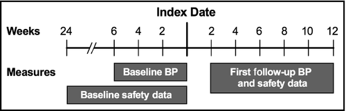

**Figure 1**

Timeline of blood pressure (BP) and safety data collected at baseline and first follow-up

### 2.2 Outcome measurements

The primary outcome was change in systolic BP (SBP) from baseline (most recent outpatient BP measurement within 6 weeks prior to the index date) to first follow-up visit (earliest outpatient BP measurement between 2 and 12 weeks after the index date). Secondary outcomes included change in diastolic BP (DBP) from baseline to first follow-up visit and proportion of patients achieving BP goal, defined as SBP <140 mm Hg and DBP <90 mm Hg according to then-current national evidence-based recommendations.9, 10 BP measurements were performed within the context of usual clinical practice during outpatient visits; thus, the timing of BP measurements was not assessed.

### 2.3 Statistical analysis

Patient demographics and baseline characteristics were summarized using descriptive statistics. Follow-up BP measurements were summarized by mean±standard deviation or percentages, and number of reported adverse effects and discontinuations of lisinopril were reported as percentages. Individual general linear regression models were used for change in SBP and DBP by treatment group, adjusting for age, sex, race (black vs all other), and time between baseline and follow-up assessments. Sensitivity analyses were performed by excluding patients identified as potential highly influential points via regression diagnostic parameters (eg, studentized residuals). Secondary analyses, adjusting for body mass index, were conducted on SBP and DBP in the cohort of patients with available data. Additionally, among patients who did not meet BP goals at baseline, logistic regression models were used to estimate the odds ratio of achieving SBP or DBP goals at follow-up comparing treatment groups, adjusting for age, sex, race, and time between baseline and follow-up visits. Given approximately 50% of serum creatinine and potassium measurements were missing, statistical tests were not performed. All analyses were performed using SAS version 9.4 (SAS Institute, Cary NC, USA).

## 3 Results

Overall, 146 patients met our study criteria. Of these, 45 patients were prescribed twice-daily lisinopril. Of the 101 patients who met criteria for the once-daily group, 45 were randomly selected using a random number generator to achieve a 1:1 ratio between groups. Baseline characteristics of the two groups are summarized in Table 1. The mean age of the study population was 62 years, 17.8% were black, and 20% had stage 3 chronic kidney disease or worse at baseline. First follow-up BP was obtained at a mean of 42.6±30.2 days. First follow-up serum creatinine and potassium concentrations were obtained at a mean of 42.8±24.9 days.

Table 1. Baseline Characteristics of the Study Cohorts

| Characteristic | Once-Daily Cohort n=45 | Twice-Daily Cohort n=45 |
| --- | --- | --- |
| Age, y | 61.8±14.5 | 63.3±14.6 |
| Women | 25 (55.7) | 20 (44.4) |
| BMI, kg/m<sup>2</sup>a | 29.6±6.6 | 29.5±6.1 |
| Race |  |  |
| Asian | 4 (8.9) | 0 |
| Black | 11 (24.4) | 5 (11.1) |
| Caucasian | 26 (57.8) | 35 (77.8) |
| Other | 3 (6.7) | 2 (4.4) |
| Unknown | 1 (2.2) | 3 (6.7) |
| Ethnicity |  |  |
| Hispanic | 4 (8.9) | 5 (11.1) |
| Non-Hispanic | 37 (82.2) | 40 (88.9) |
| Unknown | 4 (8.9) | 0 |
| Insurance coverage |  |  |
| Medicare | 28 (62.2) | 27 (60) |
| Medicaid | 3 (6.7) | 3 (6.7) |
| Commercial | 10 (22.2) | 13 (28.9) |
| Other/unknown | 4 (8.9) | 2 (4.4) |
| Hypertension monotherapy | 22 (48.9) | 26 (57.8) |
| Number of additional antihypertensive agents, median (IQR) | 1 (0–1) | 0 (0–1) |
| Other antihypertensive agents used |  |  |
| β blocker | 14 (31.1) | 7 (15.6) |
| Thiazide diuretic | 9 (20) | 7 (15.6) |
| Loop diuretic | 2 (4.4) | 3 (6.7) |
| α blocker | 0 | 1 (2.2) |
| Potassium-sparing diuretic | 1 (2.2) | 0 |
| Dihydropyridine CCB | 9 (20) | 7 (15.6) |
| Nondihydropyridine CCB | 0 | 0 |
| Other | 2 (4.4) | 1 (2.2) |
| Baseline SBP, mm Hg | 150.7±15.3 | 148.5±18.3 |
| Baseline DBP, mm Hg | 85.3±11.9 | 85.6±12.3 |
| Baseline SBP <140 mm Hg | 11 (24.4) | 11 (24.4) |
| Baseline DBP <90 mm Hg | 27 (60) | 28 (62.2) |
| Baseline BP <140/90 mm Hg | 8 (17.78) | 8 (17.78) |
| eGFR, mL/min/1.73 m<sup>2</sup>b | 74.5±31.9 | 65.1±24.9 |
| Stage 3 or worse CKD (eGFR <59 mL/min/1.73 m<sup>2</sup>) | 7 (15.6) | 11 (37.9) |
| Baseline serum potassium, mEq/Lc | 4.1±0.54 | 4.0±0.49 |
| Baseline serum creatinine, mg/dLc | 1.3±1.3 | 1.5±1.7 |

- Data are expressed as mean±standard deviation or number (percentage) unless otherwise indicated. Abbreviations: BMI, body mass index; BP, blood pressure; CCB, calcium channel blocker; CKD, chronic kidney disease; DBP, diastolic blood pressure; IQR, interquartile range; SBP, systolic blood pressure.
- <sup>*a*</sup> n=43 in the once-daily cohort, n=39 in the twice-daily cohort.
- <sup>*b*</sup> Estimated glomerular filtration rate (eGFR) calculated by Chronic Kidney Disease Epidemiology Collaboration (CKD-EPI) creatinine equation.
- <sup>*c*</sup> n=39 in the once-daily cohort, n=29 in the twice-daily cohort.

### 3.1 BP outcomes

Baseline BP was similar between groups. The mean BP achieved in the once-daily cohort was 145/84 mm Hg and the mean BP achieved in the twice-daily cohort was 131/79 mm Hg. Mean adjusted SBP reduction was 10.2 mm Hg greater in the twice-daily cohort compared with the once-daily cohort (*P*=.0159). Mean adjusted DBP reduction was 4.3 mm Hg greater in the twice-daily cohort compared with the once-daily cohort (*P*=.0675).

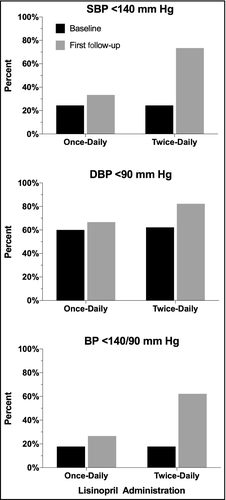

**Figure 2**

Blood pressure (BP) goal achievement at baseline and first follow-up. DBP indicates diastolic BP; SBP, systolic BP.

Four observations were flagged as potentially influential in the SBP models, and six were flagged as potentially influential in the DBP models; these patients all had larger than average decreases in BP. However, sensitivity analyses excluding these patients from the models revealed similar results (data not shown).

### 3.2 Safety outcomes

Baseline and first follow-up measurements for serum creatinine and potassium were available for 21 (46.7%) patients in the once-daily cohort and 16 (35.6%) patients in the twice-daily cohort (Table 2). All patients who had potassium measurements at either baseline or first follow-up also had serum creatinine measurements and vice versa. The mean change in serum potassium was 0.18±0.77 mEq/L in the once-daily cohort and 0.10±0.47 mEq/L in the twice-daily cohort, where positive values indicate increases. The mean change in serum creatinine was 0.17±0.33 mg/dL in the once-daily cohort and −0.08±0.50 mg/dL in the twice-daily cohort. No statistical tests for comparisons were performed between groups because of missing data.

Table 2. Safety Outcome Measurements

| Safety Events | Once-Daily Cohort, No. (%) | Twice-Daily Cohort, No. (%) |
| --- | --- | --- |
| Patients with baseline and first follow-up serum potassium and creatinine | 21 (100) | 16 (100) |
| Serum potassium >5 mg/dL | 1 (4.8) | 1 (6.3) |
| Acute kidney injury defined by serum creatinine increase of 0.3 mg/dL | 4 (19) | 1 (6.3) |
| Acute kidney injury defined by serum creatinine increase of 50% | 2 (9.5) | 0 |
| Reported adverse effecta | 2 (4.4) | 1 (2.2) |
| Discontinuation of lisinopril due to adverse effecta | 2 (4.4) | 1 (2.2) |

- <sup>*a*</sup> n=45.

One patient from each cohort had serum potassium >5 mg/dL at follow-up. In addition, four patients from the once-daily cohort and one patient from the twice-daily cohort met the modified AKI criteria.11 Lisinopril was not discontinued and the dosing regimen was not modified for these patients.

The proportion of patients who reported adverse effects in each cohort is shown in Table 2. No patients had follow-up SBP <90 mm Hg; two patients from the twice-daily cohort had follow-up DBP <60 mm Hg, but patient-reported hypotensive symptoms were not documented in either patient's chart. Three symptomatic adverse effects were reported, including angioedema (n=1) and cough (n=1) in the once-daily cohort and dizziness (n=1) in the twice-daily cohort. All patients who reported symptomatic adverse effects discontinued lisinopril.

## 4 Discussion

We show for the first time that twice-daily dosing of lisinopril was associated with greater SBP lowering and greater achievement of SBP control than once-daily dosing at the same total daily dose. This finding is consistent with studies of enalapril, an angiotensin-converting enzyme inhibitor with a similar pharmacokinetic profile.8 One probable reason for greater BP reduction with lisinopril twice-daily dosing is that lisinopril has an elimination half-life of approximately 12 hours, and its BP-lowering effects may wane towards the end of the dosing cycle.12 Thus, some patients may not get complete 24-hour BP control with once-daily lisinopril. Interestingly, previous research using 24-hour ambulatory BP monitoring has suggested that once-daily lisinopril dosing is associated with a trough to peak ratio of 0.75, which is generally considered favorable for once-daily administration of antihypertensives.13 Whether and to what extent twice-daily lisinopril dosing improves on this trough to peak ratio is not known.

Greater BP control has been a major focus of recent public and population health initiatives. However, most patients require more than one antihypertensive to control their BP.14 Given that twice-daily lisinopril appears to be more effective at reducing BP, switching to twice-daily dosing for patients who are close to BP goal may delay initiation of another antihypertensive agent, and thereby decrease polypharmacy, associated costs, and risk of adverse drug reaction. Previous studies have shown that patients taking multidrug regimens are less likely to be adherent to their full regimen.15, 16 On the other hand, twice-daily dosing frequency of cardiovascular medications is associated with greater nonadherence compared with once-daily dosing.17 As such, providers may be inclined to limit twice-daily prescribing in order to minimize barriers to adherence. However, in terms of optimizing adherence, it is not known whether there is a clear advantage between a one-drug regimen dosed twice daily and a two-drug regimen dosed once daily. Because of our study design, adherence could not be assessed. Accordingly, we cannot rule out the possibility that selection bias played a role in the substantial differences in BP lowering observed between once- and twice-daily dosing. In other words, it is possible that prescribers opted for twice-daily dosing in patients who they thought were more likely to be adherent and once-daily dosing in patients who they thought were less likely to be adherent. Greater adherence in the twice-daily dosing group could be a significant driver of greater antihypertensive efficacy. However, research suggests there is a disparity between provider-perceived patient adherence and actual patient adherence, thus the effect of this selection bias is unknown.18

Several patients (17.8% of each cohort) were already at BP goal <140/90 mm Hg at baseline, which poses the question of why their total daily dose of lisinopril was increased at the visit. Possible reasons may include provider preference, patient-specific BP goals (eg, kidney disease), or documentation error. For these patients, no documentation was found during chart review regarding reasons why the lisinopril dose was increased.

## 5 Study Limitations

There are several limitations to our study. This was a retrospective review of one health system and our findings may not be generalizable to other sites. Given that this study was retrospective, efficacy and safety measurements could not be adjudicated and patient adherence could not be assessed. In addition, as BP measurements were taken during outpatient visits, time between lisinopril doses and BP measurement could not be determined to assess whether the measurement was taken during peak or trough of the BP-lowering effect of lisinopril. A future prospective study, incorporating 24-hour ambulatory BP monitoring and evaluating adherence could overcome these limitations. Adverse effects were self-reported by patients; therefore, accuracy and completeness of the data were subject to patients’ willingness to report and providers’ thoroughness with assessing such events. Presumably, some patient adverse effects were not captured, including any events noted during inpatient or emergency department visits, but such incomplete data capture was likely to have been evenly distributed between groups. Finally, our data show an association between greater BP reductions and twice-daily dosing of lisinopril; however, because this study was retrospective in nature, our results should not be construed as proof of a causal relationship.

## 6 Conclusions

Our findings suggest that twice-daily dosing of lisinopril is more effective than conventional once-daily dosing of lisinopril, without evidence of increased adverse effects. Maximizing an already existing therapy before adding a new agent decreases polypharmacy, which may reduce cost, risk of drug-drug interactions, and patient confusion about their medications. However, twice-daily dosing may impair patient adherence, so this dosing strategy may be preferred for carefully selected patients, such as those who have demonstrated high adherence to other twice-daily medications, those with uncontrolled BP who do not want to add another antihypertensive, or those who have more difficult to treat hypertension. Further studies are needed to validate these findings in a more heterogeneous population to provide greater insight into the safety of twice-daily lisinopril dosing and the trade-off between greater BP reductions and greater treatment burden with twice-daily administration.

## Disclosures

The authors report no specific funding in relation to this research and no conflicts of interest to disclose.

## Citing Literature

[figure not shown]

[Volume19, Issue9](https://onlinelibrary.wiley.com/toc/17517176/2017/19/9)

September 2017

Pages 868-873

[figure not shown]

[figure not shown]